# CART & Logistic Regression on Titanic Dataset

Χρήστος Γιαμακίδης Κιοσσές (ics21018)

2025-05-21

## Εισαγωγή

### Περιγραφή του Dataset

Το [**Titanic - Machine Learning from Disaster**](https://www.kaggle.com/c/titanic/overview) κοινοποιήθηκε το 2012 στο *Kaggle*, ένα αποθετήριο βάσεων, συνόλων δεδομένων και θεωριών πεδίων. Εντάσσεται στον χώρο της μηχανικής μάθησης και χρησιμοποιείται ευρέως για σκοπούς εκπαίδευσης και επίδειξης αλγορίθμων ταξινόμησης. Βασίζεται στο ναυάγιο του Τιτανικού, του διάσημου επιβατηγού πλοίου που βυθίστηκε το 1912 και περιέχει πληροφορίες για τους επιβάτες. Στόχος του είναι η πρόβλεψη της επιβίωσης (Survived) κάθε επιβάτη, με βάση τα χαρακτηριστικά του.

### Επιχειρηματική Αναλυτική

Η ανάλυση των δεδομένων του dataset βοηθά την κατανόηση των παραγόντων που επηρέασαν την πιθανότητα επιβίωσης των επιβατών. Αν και πρόκειται για ιστορικά δεδομένα, η πρακτική αξία της ανάλυσης έγκειται στην **εκπαίδευση μοντέλων πρόβλεψης**, την **ανάλυση συμπεριφοράς** και την **ανάπτυξη ικανοτήτων** στην *επεξεργασία* και *ερμηνεία* δεδομένων, που είναι κρίσιμες σε πραγματικά επιχειρησιακά περιβάλλοντα.

## Περιγραφή των Μεταβλητών

Το train dataset αποτελείται από 891 εγγραφές και 12 μεταβλητές.

Αναλυτικός πίνακας με τα στοιχεία των επιβατών του Τιτανικού:

Μεταβλητή

Περιγραφή

Τύπος

Εύρος

Μονάδα Μέτρησης

PassengerId

Αναγνωριστικό Επιβάτη

Αριθμητική

1 - 891

Survived

Κατάφερε να επιβιώσει (ναι/όχι)

Αριθμητική

0 - 1

Pclass

Κατηγορία Εισιτηρίου

Αριθμητική

1 - 3

Name

Όνομα

Κατηγορική

Calic, Mr. Petar, Markoff, Mr. Marin, Kelly, Miss. Anna Katherine “Annie Kate”, Moor, Mrs. (Beila), Douglas, Mr. Walter Donald

Sex

Φύλλο

Κατηγορική

female, male

Age

Ηλικία

Αριθμητική

NA - NA

Έτη

Sibsp

Αριθμός αδελφών/συζύγου στο πλοίο

Αριθμητική

0 - 8

Parch

Αριθμός γονέων/παιδιών στο πλοίο

Αριθμητική

0 - 6

Ticket

Αριθμός εισιτηρίου

Κατηγορική

349224, 19928, 19943, 370365, PC 17558

Fare

Τιμή εισιτηρίου

Αριθμητική

0 - 512.3292

Δολλάρια ($)

Cabin

Αριθμός καμπίνας

Κατηγορική

B101, D7, E50, D35, B42

Embarked

Λιμάνι επιβίβασης

Κατηγορική

, C, Q, S

## Έλεγχος εγκυρότητας του dataset

Παρατηρούμε πως το dataset έχει κάποια **missing values**, καθώς στο εύρος των τιμών για τις ηλικίες των επιβατών εμφανίζεται NA. Επιπλέον στην μεταβλητή που δείχνει σε ποιο λιμάνι επιβιβάστηκε ο πελάτης φαίνεται να υπάρχει empty string ““, πριν τους χαρακτηριστικούς τύπους **C = Cherbourg**, **Q = Queenstown** και **S = Southampton**.

**Ελλιπείς Τιμές**

```r
cat(sum(is.na(train)))
```

```
## 177
```

**Διπλότυπες Εγγραφές**

```r
cat(sum(duplicated(train)))
```

```
## 0
```

Αφαιρούμε από το dataset τις εγρραφές που έχουν missing values.

```r
train$Embarked[train$Embarked == ""] <- NA
clean_train <- na.omit(train)
```

Πινακας με τις εγγραφές που είχαν NA’s:

Μεταβλητή

Περιγραφή

Τύπος

Εύρος

Μονάδα Μέτρησης

Age

Ηλικία Επιβάτη

Αριθμητική

0.42 - 80

Έτη

Embarked

Λιμάνι επιβίβασης

Κατηγορική

C, Q, S

```
## Συνολικές εγγραφές του dataset μετά την αφαίρεση των ελλειπών τιμών: 712
```

## Λογιστική Παλινδρόμηση

Κατανομή των τιμών της *εξαρτημένης* μεταβλητής Survived του dataset:

```r
table(clean_train$Survived)
```

```
##
##   0   1
## 424 288
```

```r
baseaccprop <- (288/712)*100
cat(round(baseaccprop, digits = 1))
```

```
## 40.4
```

**Σχόλιο**  
Παρατηρείται πως μόνο οι 288 επιβάτες από τους 712 κατάφεραν να επιβιώσουν. Έαν λοιπόν προβλέψουμε ότι όλοι οι επιβάτες του πλοίου σώθηκαν τότε σύμφωνα με την μέθοδο της **απλής βάσης** θα πετύχουμε το αποτέλεσμα με ακρίβεια της τάξης του *40.4%*. Εφαρμόζοντας τη λογιστική παλινδρόμηση στοχεύουμε στην καλύτερη ικανότητα αναγνώρισης των διασωθέντων επιβατών, δηλαδή στην αύξηση του παραπάνω ποσοστού πρόβλεψης.

### Προετοιμασία των δεδομένων

Μετατρέπουμε όλες τις κατηγορικές μεταβλητές σε factors.

```r
clean_train$Survived <- as.factor(clean_train$Survived)
clean_train$Pclass <- as.factor(clean_train$Pclass)
clean_train$Sex <- as.factor(clean_train$Sex)
clean_train$Cabin <- as.factor(clean_train$Cabin)
clean_train$Embarked <- as.factor(clean_train$Embarked)
```

### Δημιουργία Μοντέλου Λογιστικής Παλινδρόμησης

Αφαιρούμε από το μοντέλο της ανεξάρτητες μεταβλητές *PassengerId*, *Name* και *Ticket*, καθώς αυτές αποτελούν **μοναδικά αναγνωριστικά** για κάθε επιβάτη και άρα δεν έχουν κάποια επίδραση στο αποτέλεσμα της πρόβλεψης.

```r
LRmodel <- glm(Survived ~ Pclass + Cabin + Sex + Age + SibSp + Parch + Fare + Embarked, data = clean_train, family = "binomial")
summary(LRmodel)
```

```
##
## Call:
## glm(formula = Survived ~ Pclass + Cabin + Sex + Age + SibSp +
##     Parch + Fare + Embarked, family = "binomial", data = clean_train)
##
## Coefficients:
##                        Estimate Std. Error z value Pr(>|z|)
## (Intercept)           3.972e+00  8.258e-01   4.809 1.51e-06 ***
## Pclass2              -7.848e-01  6.233e-01  -1.259 0.208016
## Pclass3              -1.868e+00  6.516e-01  -2.866 0.004153 **
## CabinA10             -1.848e+01  6.523e+03  -0.003 0.997739
## CabinA16              1.709e+01  6.523e+03   0.003 0.997910
## CabinA20              1.964e+01  6.523e+03   0.003 0.997598
## CabinA23              2.128e+01  6.523e+03   0.003 0.997397
## CabinA24             -1.842e+01  6.523e+03  -0.003 0.997747
## CabinA26              1.966e+01  6.523e+03   0.003 0.997595
## CabinA31              1.892e+01  6.523e+03   0.003 0.997685
## CabinA34              1.717e+01  6.523e+03   0.003 0.997900
## CabinA36             -1.758e+01  6.523e+03  -0.003 0.997849
## CabinA5              -1.673e+01  6.523e+03  -0.003 0.997953
## CabinA6               1.870e+01  6.523e+03   0.003 0.997713
## CabinA7              -1.743e+01  6.523e+03  -0.003 0.997868
## CabinB101             1.443e+01  6.523e+03   0.002 0.998234
## CabinB18              1.570e+01  4.425e+03   0.004 0.997169
## CabinB19             -1.681e+01  6.523e+03  -0.003 0.997944
## CabinB20              1.805e+01  3.685e+03   0.005 0.996091
## CabinB22             -1.471e-03  2.620e+00  -0.001 0.999552
## CabinB3               1.525e+01  6.523e+03   0.002 0.998135
## CabinB30             -1.724e+01  6.523e+03  -0.003 0.997891
## CabinB35              1.515e+01  4.612e+03   0.003 0.997379
## CabinB37             -1.732e+01  6.523e+03  -0.003 0.997881
## CabinB38             -1.753e+01  6.523e+03  -0.003 0.997856
## CabinB39              1.528e+01  6.523e+03   0.002 0.998131
## CabinB4               1.649e+01  6.523e+03   0.003 0.997983
## CabinB41              2.000e+01  6.523e+03   0.003 0.997554
## CabinB42              1.566e+01  6.523e+03   0.002 0.998085
## CabinB49              1.714e+01  3.798e+03   0.005 0.996400
## CabinB5               1.425e+01  4.565e+03   0.003 0.997510
## CabinB50              1.854e+01  6.523e+03   0.003 0.997732
## CabinB51 B53 B55     -1.706e+00  2.928e+00  -0.583 0.560082
```

[output cut: 105 more lines]

```
## SibSp                -5.037e-01  1.508e-01  -3.341 0.000835 ***
## Parch                -2.407e-02  1.362e-01  -0.177 0.859708
## Fare                  8.820e-03  6.854e-03   1.287 0.198179
## EmbarkedQ            -7.944e-01  6.627e-01  -1.199 0.230622
## EmbarkedS            -4.011e-01  3.623e-01  -1.107 0.268273
## ---
## Signif. codes:  0 '***' 0.001 '**' 0.01 '*' 0.05 '.' 0.1 ' ' 1
##
## (Dispersion parameter for binomial family taken to be 1)
##
##     Null deviance: 960.90  on 711  degrees of freedom
## Residual deviance: 490.18  on 569  degrees of freedom
## AIC: 776.18
##
## Number of Fisher Scoring iterations: 17
```

*Ερμηνεία Συσχετίσεων*  
Θεωρούμε στατιστικά σημαντικές τις ανεξάρτητες μεταβλητές που στη στήλη `Pr(>|z|)` έχουν τιμές **<0.01**, δηλαδή αυτές που έχουν τουλάχιστον δύο ** από δίπλα τους.

Στατιστικά σημαντικές μεταβλητές (p < 0.01):

| Μεταβλητή | Συντελεστής (Estimate) | P-value | Επίδραση |
| --- | --- | --- | --- |
| Pclass3 | -1.868e+00 | 0.004153 | Ισχυρή |
| Sexmale | -2.655e+00 | < 2e-16 | Πολύ ισχυρή |
| Age | -4.868e-02 | 3.43e-06 | Αρκετά ισχυρή |
| SibSp | -5.037e-01 | 0.000835 | Ισχυρή |

**Παρατηρήσεις:**

- Εάν το εισιτήριο του επιβάτη ανήκει στην 2η (ή και 3η όπως θα δούμε παρακάτω) κατηγορία, τότε η πιθανότητα επιβίωσης **μειώνεται**.
- Εάν ο επιβάτης είναι άνδρας, τότε η πιθανότητα επιβίωσης **μειώνεται**.
- Όσο μεγαλύτερος είναι ο επιβάτης ηλικιακά, τόσο **μικρότερη** είναι η πιθανότητα επιβίωσης.
- Η ύπαρξη αδελφών ή και συζύγου στο πλοίο **μειώνει** την πιθανότητα επιβίωσης του επιβάτη.

### Διαδικασία αφαίρεσης μεταβλητών

Με βάση τον παραπάνω πίνακα, έχει νοήμα να κρατήσουμε στο τελικό μοντέλο της λογιστικής παλινδρόμησης τις ανεξάρτητες μεταβλητές *Pclass*, *Sex*, *Age* και *SibSp*.

```r
LRmodel2 <- glm(Survived ~ Pclass + Sex + Age + SibSp , data = clean_train, family = "binomial")
summary(LRmodel2)
```

```
##
## Call:
## glm(formula = Survived ~ Pclass + Sex + Age + SibSp, family = "binomial",
##     data = clean_train)
##
## Coefficients:
##              Estimate Std. Error z value Pr(>|z|)
## (Intercept)  4.325373   0.450707   9.597  < 2e-16 ***
## Pclass2     -1.406282   0.284836  -4.937 7.93e-07 ***
## Pclass3     -2.644961   0.285906  -9.251  < 2e-16 ***
## Sexmale     -2.618972   0.215008 -12.181  < 2e-16 ***
## Age         -0.044938   0.008237  -5.456 4.88e-08 ***
## SibSp       -0.378564   0.121377  -3.119  0.00182 **
## ---
## Signif. codes:  0 '***' 0.001 '**' 0.01 '*' 0.05 '.' 0.1 ' ' 1
##
## (Dispersion parameter for binomial family taken to be 1)
##
##     Null deviance: 960.90  on 711  degrees of freedom
## Residual deviance: 636.04  on 706  degrees of freedom
## AIC: 648.04
##
## Number of Fisher Scoring iterations: 5
```

**Σχόλιο**  
Όπως φαίνεται και από τον δείκτη AIC, το δεύτερο μοντέλο λογιστικής παλινδρόμησης προβλέπει καλύτερα την πιθανότητα της επιβίωσης.

- **LRmodel**: AIC = 776.18
- **LRmodel2**: AIC = 648.04

### Εισαγωγή και προετοιμασία του test set

```r
test <- read.csv("test.csv")
clean_test <- na.omit(test)
clean_test$Survived <- as.factor(clean_test$Survived)
clean_test$Pclass <- as.factor(clean_test$Pclass)
clean_test$Sex <- as.factor(clean_test$Sex)
```

### Προβλέψεις τιμών στο test set

```r
predictTest <- predict(LRmodel2, newdata = clean_test, type = "response")
```

### Confusion Matrix

```r
threshold <- 0.5
pred_class <- ifelse(predictTest >= threshold, "Survived", "Died")
pred_class <- factor(pred_class, levels = c("Died", "Survived"))
actual_class <- factor(clean_test$Survived, levels = c(0, 1), labels = c("Died", "Survived"))

conf_mat <- table(Predicted = pred_class, Actual = actual_class)
print(conf_mat)
```

```
##           Actual
## Predicted  Died Survived
##   Died      188       10
##   Survived   16      117
```

```r
cat("Accuracy =", sum(diag(conf_mat)) / sum(conf_mat), "\n",
    "Sensitivity =", conf_mat["Survived", "Survived"] / sum(conf_mat[, "Survived"]), "\n",
    "Specificity =", conf_mat["Died", "Died"] / sum(conf_mat[, "Died"]))
```

```
## Accuracy = 0.9214502
##  Sensitivity = 0.9212598
##  Specificity = 0.9215686
```

**Σχόλιο**  
Σαφώς πιο **βελτιωμένη** η τιμή του Accuracy στο μοντέλο της λογιστικής παλινδρόμησης από την αντίστοιχη του baseline (0.404).

### Καμπύλη ROC και AUC

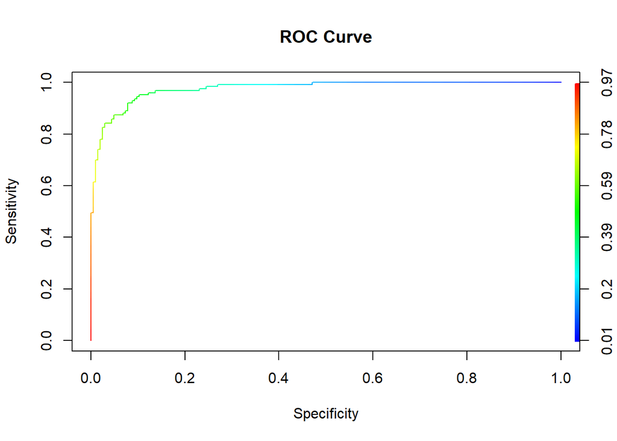

```r
ROCRpredLR <- prediction(predictTest, clean_test$Survived)
ROCperf <- performance(ROCRpredLR, "tpr", "fpr")
plot(ROCperf, colorize = TRUE, main = "ROC Curve", xlab = "Specificity", ylab = "Sensitivity")
```

```r
cat("AUC =", as.numeric(performance(ROCRpredLR, "auc")@y.values))
```

```
## AUC = 0.9759148
```

## Δέντρο Απόφασης

### Cross Validation

```r
numFolds <- trainControl(method = "cv", number=7)
cpGrid <- expand.grid(.cp = seq(0.01,0.47,0.01))
train(Survived ~ Pclass + Sex + Age + SibSp + Parch + Fare + Cabin + Embarked, data=clean_train, method="rpart", trControl=numFolds, tuneGrid=cpGrid)
```

```
## CART
##
## 712 samples
##   8 predictor
##   2 classes: '0', '1'
##
## No pre-processing
## Resampling: Cross-Validated (7 fold)
## Summary of sample sizes: 610, 611, 610, 610, 609, 611, ...
## Resampling results across tuning parameters:
##
##   cp    Accuracy   Kappa
##   0.01  0.8060944  0.57757756
##   0.02  0.7963318  0.56460612
##   0.03  0.7794557  0.52728267
##   0.04  0.7738529  0.51819048
##   0.05  0.7795107  0.53450047
##   0.06  0.7795107  0.53450047
##   0.07  0.7795107  0.53450047
##   0.08  0.7795107  0.53450047
##   0.09  0.7795107  0.53450047
##   0.10  0.7795107  0.53450047
##   0.11  0.7795107  0.53450047
##   0.12  0.7795107  0.53450047
##   0.13  0.7795107  0.53450047
##   0.14  0.7795107  0.53450047
##   0.15  0.7795107  0.53450047
##   0.16  0.7795107  0.53450047
##   0.17  0.7795107  0.53450047
##   0.18  0.7795107  0.53450047
##   0.19  0.7795107  0.53450047
##   0.20  0.7795107  0.53450047
##   0.21  0.7795107  0.53450047
##   0.22  0.7795107  0.53450047
##   0.23  0.7795107  0.53450047
##   0.24  0.7795107  0.53450047
##   0.25  0.7795107  0.53450047
##   0.26  0.7795107  0.53450047
##   0.27  0.7795107  0.53450047
##   0.28  0.7795107  0.53450047
##   0.29  0.7795107  0.53450047
##   0.30  0.7795107  0.53450047
##   0.31  0.7795107  0.53450047
##   0.32  0.7795107  0.53450047
##   0.33  0.7795107  0.53450047
##   0.34  0.7795107  0.53450047
##   0.35  0.7795107  0.53450047
##   0.36  0.7795107  0.53450047
##   0.37  0.7795107  0.53450047
##   0.38  0.7795107  0.53450047
##   0.39  0.7795107  0.53450047
##   0.40  0.7795107  0.53450047
##   0.41  0.7795107  0.53450047
##   0.42  0.7795107  0.53450047
##   0.43  0.7795107  0.53450047
##   0.44  0.7153976  0.35681421
##   0.45  0.6291176  0.11449984
##   0.46  0.6291176  0.11449984
##   0.47  0.6067086  0.04476307
##
## Accuracy was used to select the optimal model using the largest value.
## The final value used for the model was cp = 0.01.
```

**Σχόλιο**  
Η ιδανική τιμή για το cp που προκύπτει είναι 0.01.

### Δημιουργία μοντέλου CART

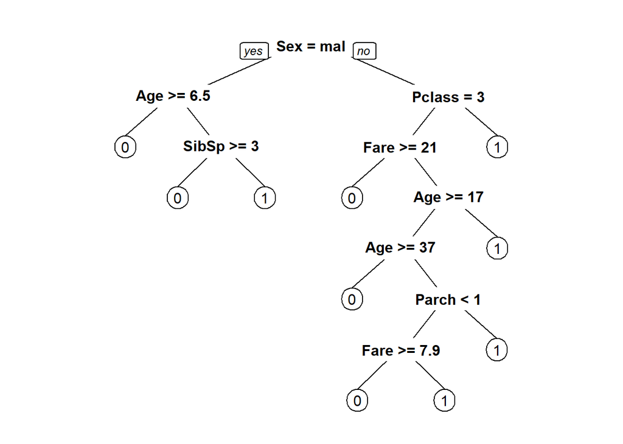

```r
SurvivedTree <- rpart(Survived ~ Pclass + Sex + Age + SibSp + Parch + Fare + Embarked, data = clean_train, method="class", cp=0.01)
prp(SurvivedTree)
```

### Προβλέψεις τιμών στο test set

```r
predictTestCart <- predict(SurvivedTree, newdata = clean_test, type = "prob")[, 2]
```

### Confusion Matrix

```r
predictTestCart_class <- predict(SurvivedTree, newdata = clean_test, type = "class")
conf_mat <- table(
  Predicted = factor(predictTestCart_class, levels = c(0, 1), labels = c("Died", "Survived")),
  Actual = factor(clean_test$Survived, levels = c(0, 1), labels = c("Died", "Survived"))
)

print(conf_mat)
```

```
##           Actual
## Predicted  Died Survived
##   Died      198       20
##   Survived    6      107
```

```r
cat("Accuracy =", sum(diag(conf_mat)) / sum(conf_mat), "\n",
    "Sensitivity =", conf_mat["Survived", "Survived"] / sum(conf_mat[, "Survived"]), "\n",
    "Specificity =", conf_mat["Died", "Died"] / sum(conf_mat[, "Died"]))
```

```
## Accuracy = 0.9214502
##  Sensitivity = 0.8425197
##  Specificity = 0.9705882
```

**Σχόλιο**  
Η τιμή του Accuracy στο μοντέλο Cart είναι ίδια με την αντίστοιχη της λογιστικής παλινδρόμησης (0.9214502). Ωστόσο το μοντέλο Cart προβλέπει 10 παραπάνω **True Negatives** και 10 λιγότερα **True Positives**, από το μοντέλο της λογιστικής παλινδρόμησης.

### Καμπύλη ROC και AUC

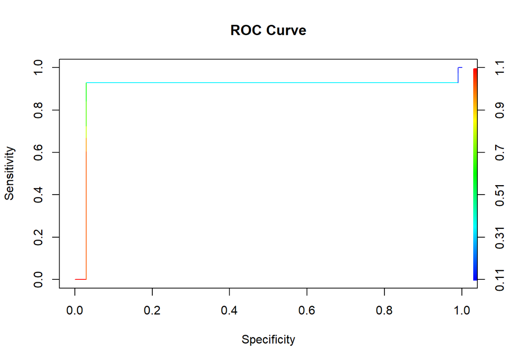

```r
ROCRpredCart <- prediction(predictTestCart, clean_test$Survived)
ROCperfCart <- performance(ROCRpredCart, "tpr", "fpr")
plot(ROCperfCart, colorize = TRUE, main = "ROC Curve", xlab = "Specificity", ylab = "Sensitivity")
```

```r
cat("AUC =", as.numeric(performance(ROCRpredCart, "auc")@y.values))
```

```
## AUC = 0.9025012
```

## Συμπεράσματα

Αναλυτικός πίνακας μετρικών:

[output not shown]

**Σχολιασμός Αποτελεσμάτων**

- Και τα δύο μοντέλα έχουν την ίδια ακρίβεια στις προβλέψεις του test set (ίδιο Accuracy / 0.921), γεγονός που δείχνει ότι είναι εξίσου ικανά στο να προβλέπουν σωστά την πιθανότητα επιβίωσης. Ωστόσο, η τιμή αυτή από μόνη της δεν επαρκεί για την πλήρη αξιολόγηση της απόδοσης, ειδικά σε περιπτώσεις ανισορροπίας μεταξύ των κλάσεων.
- Το μοντέλο της λογιστικής παλινδρόμησης παρουσιάζει υψηλότερη τιμή AUC, κάτι που δείχνει ότι είναι πιο ικανό να διαχωρίζει τις δύο κλάσεις με βάση τις προβλεπόμενες πιθανότητες. Το μοντέλο Cart από την άλλη, λόγω του διακριτού χαρακτήρα των προβλέψεών του, έχει χαμηλότερη ευελιξία στο διαχωρισμό, με συνέπεια χαμηλότερη AUC.
- Το μοντέλο της λογιστικής παλινδρόμησης έχει πιο ισορροπημένες τιμές: Sensitivity = 0.921 και Specificity = 0.922, σε αντίθεση με το μοντέλο CART που παρουσιάζει ελαφρώς πιο συντηρητική συμπεριφορά: Specificity = 0.971 και Sensitivity = 0.843. Αυτό σημαίνει πως το μοντέλο CART είναι πιο αυστηρό στο να προβλέπει την πιθανότητα επιβίωσης, με αποτέλεσμα να μειώνει τα False Positives, αλλά και να αυξάνει τα False Negatives.

Γενικότερα όταν ο στόχος της μελέτης είναι η **βέλτιστη διαχωριστική ικανότητα** μεταξύ των πιθανών αποτελεσμάτων, τότε το μοντέλο της λογιστικής παλινδρόμησης είναι καλύτερη επιλογή. Από την άλλη αν η **ερμηνευσιμότητα** είναι πιο σημαντική, τότε το μοντέλο CART προσφέρει απλούστερους και κατανοητούς κανόνες.